# Relatório Assessoria 1

2024-04-07

# Relatório Estatístico - Projeto de Pesquisa: Relações de Trabalho e os servidores com deficiência na Universidade Federal de Santa Maria (UFSM)

## Introdução

O presente relatório apresenta uma análise de dados descritiva e exploratória relativa aos dados obtidos via formulário referente ao projeto de pesquisa Relações de Trabalho e os servidores com deficiência na Universidade Federal de Santa Maria (UFSM). O objetivo geral é entender qual o significado do trabalho para os servidores com deficiência na Universidade Federal de Santa Maria (UFSM) e como o capacitismo interfere nas relações laborais desses servidores. Para concretizar o objetivo geral, o presente estudo almeja realizar os seguintes objetivos específicos:

- Mapear os servidores com deficiência na UFSM;
- Compreender como se dão suas relações de trabalho na organização e se essas são ou já foram permeadas pelo capacitismo;
- Entender qual o significado do trabalho para os servidores com deficiência na UFSM;
- Propor alternativas e indicadores para que a área de gestão de pessoas possa facilitar a inclusão de servidores com deficiência nas relações de trabalho.

## Materiais e métodos

São 54 variáveis, referentes às 54 perguntas contidas no formulário preenchido pelos servidores (a última pergunta referente ao e-mail foi removida da tabela):

- Gênero
- Qual?
- Idade:
- Estado civil:
- Qual?
- Tem filhos(as)?
- Quantos:
- Idade(s):
- Mora com (mais de uma opção pode ser marcada):
- Qual?
- Escolaridade:
- Qual(is) curso(s)/área(s) de conhecimento da(s) sua(s) formação(ões)?
- Categoria:
- Cargo:
- Nível:
- Nível:
- Carga horária semanal:
- Qual?
- Unidade de lotação:
- Possui Cargo de Direção (CD) ou Função Gratificada (FG)?
- Campus:
- Ano de ingresso como servidor na Universidade:
- Ingressou por intermédio do sistema de cotas para PCD?
- Você se sente satisfeito/realizado/reconhecido/útil no seu local de trabalho?
- Tipo de deficiência que possui:
- Qual(is)?
- Possui o diagnóstico desde:
- Causa:
- Você utiliza alguma tecnologia assistiva/recurso?
- Qual(is)?
- Se utiliza alguma tecnologia assistiva/recurso, essa é disponibilizada pela UFSM?
- Se não, como você consegue obter (através de recursos próprios, doações, etc)?
- Você necessita de algum acompanhamento ou apoio de outra pessoa para realizar as atividades cotidianas no ambiente de trabalho?
- Se necessita, em quais atividades?
- Esse acompanhamento/apoio é disponibilizado pela UFSM?
- Se não, como você consegue obter?
- De um modo geral, como você considera o nível de acessibilidade arquitetônica da UFSM (Exemplos: rampas, elevadores e banheiros adaptados, calçadas com piso tátil, vagas reservadas em estacionamentos, etc)?
- De um modo geral, como você considera o nível de acessibilidade atitudinal da UFSM (incentivo a percepções sem preconceitos, discriminações e estigmas)?
- De um modo geral, como você considera o nível de acessibilidade instrumental/digital da UFSM (Ex: software de leitor de tela no computador, sites e aplicativos institucionais acessíveis e ferramentas que eliminem barreiras digitais e de instrumentos de trabalho)?
- De um modo geral, como você considera o nível de acessibilidade comunicacional da UFSM (oferecimento de recursos e atividades que promovam a independência no acesso a qualquer conteúdo. Isso inclui legendas, áudios, descrições, Libras, braile, etc)?
- Você conhece a legislação brasileira sobre acessibilidade?
- Qual seu objetivo quando fez o concurso para a UFSM (mais de uma opção pode ser marcada)?
- Qual(is)?
- Você sentiu dificuldade de adaptação durante o ingresso nas atividades laborais na UFSM?
- Se sim, poderia relatar? Como foi resolvido?
- Você enfrentou algum problema de relacionamento interpessoal com chefias e/ou colegas?
- Se sim, poderia relatar? Como foi resolvido?
- Você já foi parte reclamante, na UFSM, em algum Processo administrativo disciplinar (PAD), Sindicância e/ou reclamatória trabalhista?
- Você considera que a UFSM dispõe de recursos humanos e materiais suficientes para atender necessidades que possam eventualmente surgir relacionadas a acessibilidade?
- Se não, poderia relatar o que considera insuficiente?
- Você participa de alguma associação, sindicato, ou outros grupos de luta por defesa de direitos trabalhistas?
- Qual?
- Se participa, você sente que as pautas das PCD são consideradas nas ações dessa associação/sindicato/grupo?
- Espaço para outros comentários e informações que você queira nos passar sobre inclusão e acessibilidade na UFSM:

## Análise Descritiva

Nesta seção iremos desenvolver as seguintes análises:

- Gênero X grau de satisfação (em todas as questões de acessibilidade)
- Campi x grau de satisfação (em todas as questões de acessibilidade)
- Idade X grau de satisfação (em todas as questões de acessibilidade)
- Tipos de deficiência mais comum X grau de satisfação (em todas as questões de acessibilidade)
- Data de ingresso X entrada por cotas
- Idade X conhecimento da legislação
- Objetivo de fazer o concurso X grau de satisfação.
- Satisfação X tempo de serviço
- Satisfação X escolaridade
- Satisfação X setores

### Gênero x Grau de satisfação para questões de acessibilidade

Na nossa base de dados temos o mesmo número de pessoas no sexo feminino e masculino, ambos com 32 pessoas. Abaixo temos o gráfico de barras que mostra a quantidade de respostas em cada nível para cada gênero para questões de opinião em relação à acessibilidade.

Em relação acessibilidade arquitetônica da UFSM (Exemplos: rampas, elevadores e banheiros adaptados, calçadas com piso tátil, vagas reservadas em estacionamentos, etc), os homens parecem estar mais satisfeitos do que as mulheres, em geral. Cerca de 37,5% das mulheres responderam bom ou ótimo e, para os homens, este percentual fica em 46,9%.

[figure not shown]

Em relação acessibilidade instrumental/digital da UFSM (Ex: software de leitor de tela no computador, sites e aplicativos institucionais acessíveis e ferramentas que eliminem barreiras digitais e de instrumentos de trabalho), os homens também parecem estar mais satisfeitos do que as mulheres, em geral. Cerca de 37,5% das mulheres responderam bom ou ótimo e, para os homens, este percentual fica em 50%.

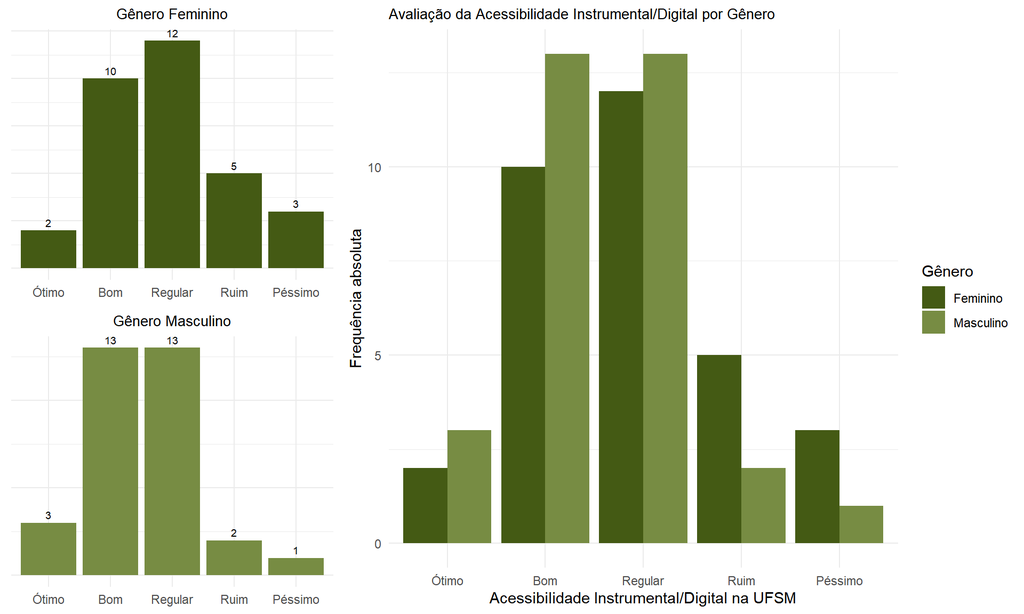

Em relação acessibilidade atitudinal da UFSM (incentivo a percepções sem preconceitos, discriminações e estigmas), os homens novamnete se mostram mais satisfeitos do que as mulheres, em geral. Cerca de 43,8% das mulheres responderam bom ou ótimo e, para os homens, este percentual fica em 59,4%.

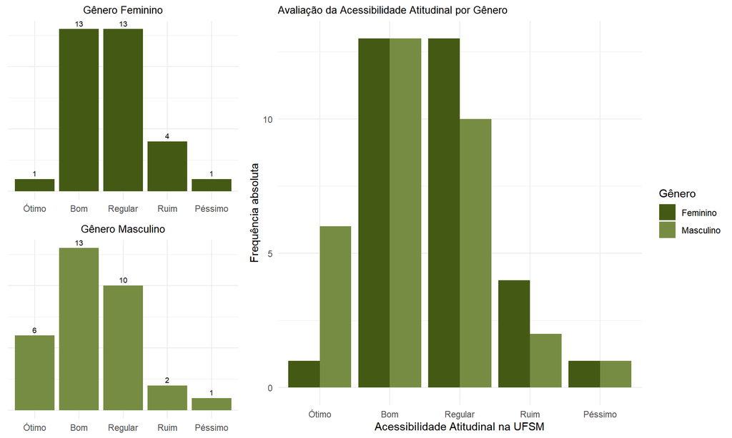

Em relação acessibilidade comunicacional da UFSM (oferecimento de recursos e atividades que promovam a independência no acesso a qualquer conteúdo. Isso inclui legendas, áudios, descrições, Libras, braile, etc), os homens novamnete se mostram mais satisfeitos do que as mulheres, em geral. Cerca de 28,1% das mulheres responderam bom ou ótimo e, para os homens, este percentual fica em 56,2%.

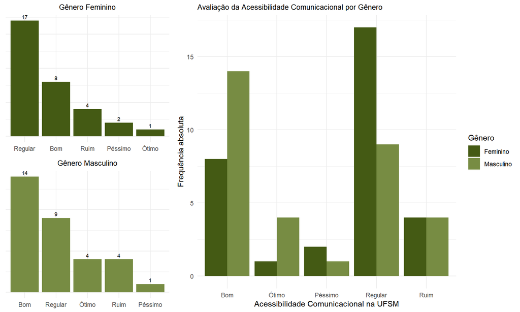

### Campi x Grau de satisfação para questões de acessibilidade

Na nossa base de dados temos 59 pessoas do campus de Santa Maria, 3 de Cachoeira do Sul, 1 de Frederico Westphalene 1 de Palmeira das Missões. Abaixo temos o gráfico de barras que mostra a quantidade de respostas em cada nível para cada campus para questões de opinião em relação à acessibilidade.

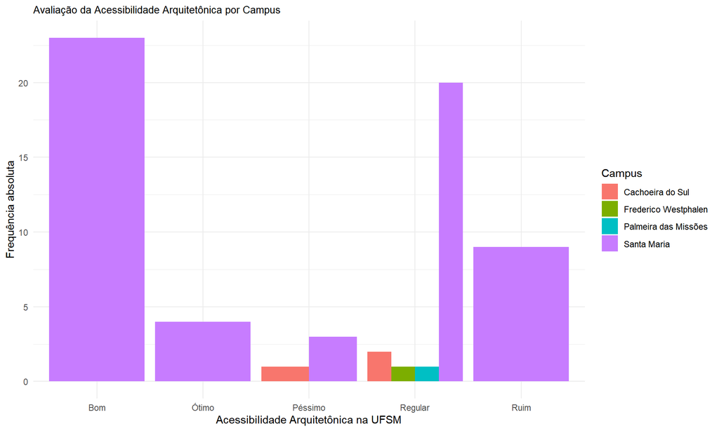

[figure not shown]

[figure not shown]

[figure not shown]

| Questão | Ótimo (%) | Bom (%) | Regular (%) | Ruim (%) | Péssimo (%) |
| --- | --- | --- | --- | --- | --- |
| Comunicacional | 12.500 | 43.750 | 28.125 | 12.500 | 3.125 |
| Atitudinal | 18.750 | 40.625 | 31.250 | 6.250 | 3.125 |
| Instrumental/Digital | 9.375 | 40.625 | 40.625 | 6.250 | 3.125 |
| Arquitetônica | 9.375 | 37.500 | 40.625 | 9.375 | 3.125 |

| Questão | Ótimo (%) | Bom (%) | Regular (%) | Ruim (%) | Péssimo (%) |
| --- | --- | --- | --- | --- | --- |
| Comunicacional | 3.125 | 25.000 | 53.125 | 12.500 | 6.250 |
| Atitudinal | 3.125 | 40.625 | 40.625 | 12.500 | 3.125 |
| Instrumental/Digital | 6.250 | 31.250 | 37.500 | 15.625 | 9.375 |
| Arquitetônica | 3.125 | 34.375 | 34.375 | 18.750 | 9.375 |